# Modeling Variations in State Education Attainment

## 3. Correlation screening

Related variables were grouped and plotted against candidate response variables to spot strong relationships, collinearity, and outliers. The percent of a state’s population with a bachelor’s degree (`per_ba`) was the most responsive outcome.

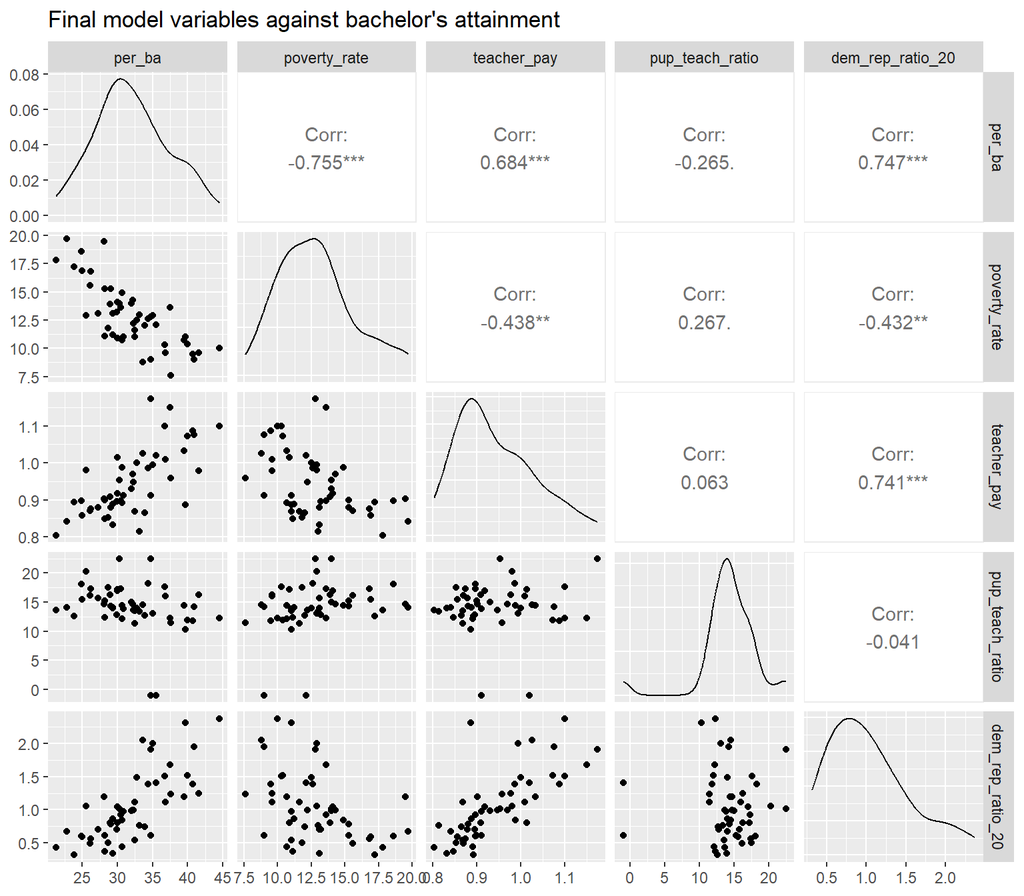

```r
final_vars <- c("per_ba", "poverty_rate", "teacher_pay",
                "pup_teach_ratio", "dem_rep_ratio_20")

ggpairs(sdata[final_vars],
        title = "Final model variables against bachelor's attainment")
```

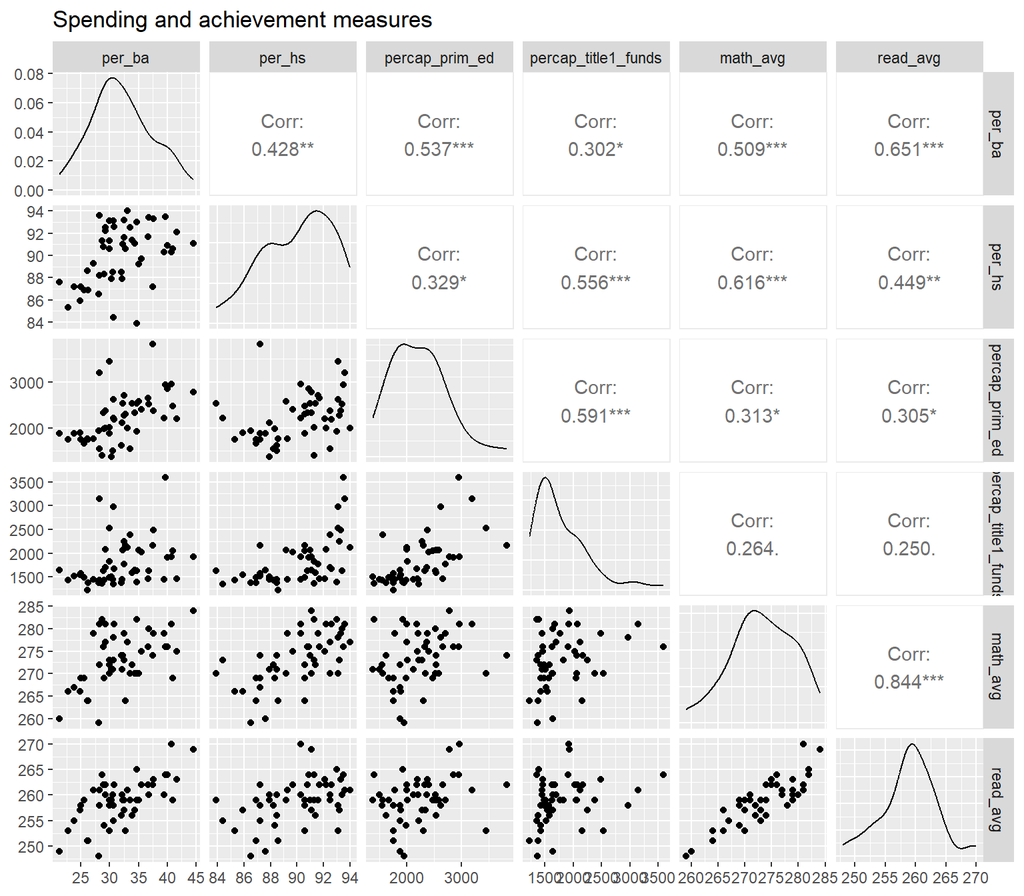

```r
# spending and achievement measures
ggpairs(sdata[c("per_ba", "per_hs", "percap_prim_ed", "percap_title1_funds",
                "math_avg", "read_avg")],
        title = "Spending and achievement measures")
```

## 4. Model type comparison

### Logistic regression

The first model type classified whether a state met or exceeded the national average on the 2022 NAEP exams. This example from the original notebooks uses primary education spending and pupil–teacher ratio to predict meeting the average on both exams.

```r
test_logm <- glm(both_moe_navg ~ percap_prim_ed + pup_teach_ratio,
                 family = "binomial", data = sdata)
summary(test_logm)
```

```
##
## Call:
## glm(formula = both_moe_navg ~ percap_prim_ed + pup_teach_ratio,
##     family = "binomial", data = sdata)
##
## Coefficients:
##                   Estimate Std. Error z value Pr(>|z|)
## (Intercept)     -0.9332290  2.4738020  -0.377   0.7060
## percap_prim_ed   0.0014828  0.0007282   2.036   0.0417 *
## pup_teach_ratio -0.1781632  0.1088838  -1.636   0.1018
## ---
## Signif. codes:  0 '***' 0.001 '**' 0.01 '*' 0.05 '.' 0.1 ' ' 1
##
## (Dispersion parameter for binomial family taken to be 1)
##
##     Null deviance: 68.994  on 49  degrees of freedom
## Residual deviance: 57.274  on 47  degrees of freedom
## AIC: 63.274
##
## Number of Fisher Scoring iterations: 4
```

```r
# confusion matrix at a 0.5 threshold
pred_class <- factor(ifelse(fitted(test_logm) >= 0.5, 1, 0), levels = c(0, 1))
table(Actual = sdata$both_moe_navg, Predicted = pred_class)
```

```
##       Predicted
## Actual  0  1
##      0 21  6
##      1 11 12
```

```r
# ROC curve and AUC
roc_obj <- roc(sdata$both_moe_navg ~ fitted(test_logm))
round(auc(roc_obj), 4)
```

```
## [1] 0.7697
```

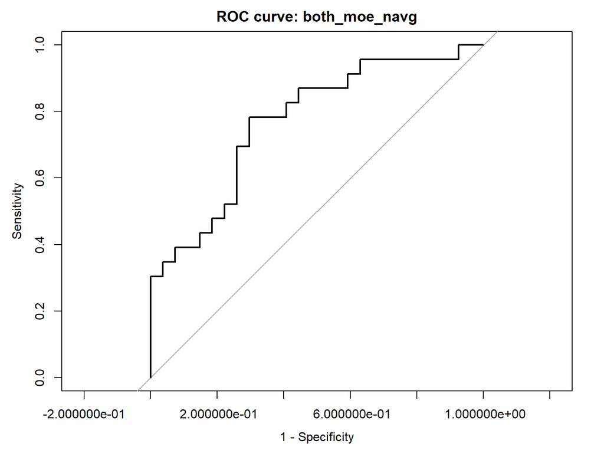

```r
plot(roc_obj, legacy.axes = TRUE, main = "ROC curve: both_moe_navg")
```

Single-predictor logistic models across the three outcomes:

```r
logit_auc <- function(response, predictor) {
  m <- glm(as.formula(paste(response, "~", predictor)),
           family = "binomial", data = sdata)
  as.numeric(auc(roc(sdata[[response]] ~ fitted(m), quiet = TRUE)))
}

predictors <- c("percap_prim_ed", "teacher_pay", "pup_teach_ratio",
                "min_hours_by8th", "poverty_rate")
responses  <- c("read_moe_navg", "math_moe_navg", "both_moe_navg")

auc_table <- sapply(responses, function(r) sapply(predictors, logit_auc, response = r))
round(auc_table, 3)
```

```
##                 read_moe_navg math_moe_navg both_moe_navg
## percap_prim_ed          0.667         0.744         0.744
## teacher_pay             0.706         0.538         0.556
## pup_teach_ratio         0.549         0.730         0.682
## min_hours_by8th         0.544         0.509         0.526
## poverty_rate            0.827         0.788         0.796
```

### Simple linear regression

```r
candidates <- c("poverty_rate", "teacher_pay", "dem_rep_ratio_20",
                "pup_teach_ratio", "percap_prim_ed", "percap_total",
                "percap_higher_ed", "percap_title1_funds", "min_hours_by8th")

simple_r2 <- sapply(candidates, function(x)
  summary(lm(as.formula(paste("per_ba ~", x)), data = sdata))$r.squared)

sort(round(simple_r2, 4), decreasing = TRUE)
```

```
##        poverty_rate    dem_rep_ratio_20         teacher_pay      percap_prim_ed
##              0.5707              0.5576              0.4674              0.2879
##        percap_total percap_title1_funds     pup_teach_ratio     min_hours_by8th
##              0.0999              0.0913              0.0701              0.0362
##    percap_higher_ed
##              0.0005
```

## 5. Building the final model

Predictors were added one at a time, and each step was compared using multiple, adjusted, and predictive R², residual standard error, and nested F-tests to guard against overfitting.

```r
lm1    <- lm(per_ba ~ poverty_rate, data = sdata)
lm12   <- lm(per_ba ~ poverty_rate + teacher_pay, data = sdata)
lm123  <- lm(per_ba ~ poverty_rate + teacher_pay + pup_teach_ratio, data = sdata)
lm1234 <- lm(per_ba ~ poverty_rate + teacher_pay + pup_teach_ratio +
               dem_rep_ratio_20, data = sdata)

fit_table <- ldply(list(lm1 = lm1, lm12 = lm12, lm123 = lm123, lm1234 = lm1234),
                   model_fit_stats, .id = "model")
fit_table[, 2:6] <- round(fit_table[, 2:6], 4)
fit_table
```

| model | r.squared | adj.r.squared | pred.r.squared | rse | press |
| --- | --- | --- | --- | --- | --- |
| lm1 | 0.5707 | 0.5617 | 0.5339 | 3.4746 | 629.1182 |
| lm12 | 0.7248 | 0.7131 | 0.6878 | 2.8112 | 421.3908 |
| lm123 | 0.7473 | 0.7308 | 0.6943 | 2.7229 | 412.5789 |
| lm1234 | 0.8151 | 0.7986 | 0.7694 | 2.3552 | 311.2129 |

```r
anova(lm1, lm12, lm123, lm1234, test = "F")
```

| Res.Df | RSS | Df | Sum of Sq | F | Pr(>F) |
| --- | --- | --- | --- | --- | --- |
| 48 | 579.5015 | NA | NA | NA | NA |
| 47 | 371.4266 | 1 | 208.07490 | 37.510398 | 0.0000002 |
| 46 | 341.0554 | 1 | 30.37117 | 5.475118 | 0.0237846 |
| 45 | 249.6207 | 1 | 91.43476 | 16.483268 | 0.0001935 |

## 6. Final model

```r
final_model <- lm1234
assess_lm(final_model)
```

```
##
## Call:
## lm(formula = per_ba ~ poverty_rate + teacher_pay + pup_teach_ratio +
##     dem_rep_ratio_20, data = sdata)
##
## Residuals:
##     Min      1Q  Median      3Q     Max
## -6.7583 -1.2509 -0.1299  1.2407  5.9611
##
## Coefficients:
##                  Estimate Std. Error t value Pr(>|t|)
## (Intercept)      30.32452    5.52027   5.493 1.75e-06 ***
## poverty_rate     -0.85539    0.14150  -6.045 2.67e-07 ***
## teacher_pay      11.68361    5.87602   1.988 0.052875 .
## pup_teach_ratio  -0.17720    0.08783  -2.018 0.049626 *
## dem_rep_ratio_20  3.98547    0.98165   4.060 0.000193 ***
## ---
## Signif. codes:  0 '***' 0.001 '**' 0.01 '*' 0.05 '.' 0.1 ' ' 1
##
## Residual standard error: 2.355 on 45 degrees of freedom
## Multiple R-squared:  0.8151, Adjusted R-squared:  0.7986
## F-statistic: 49.58 on 4 and 45 DF,  p-value: 6.232e-16
```

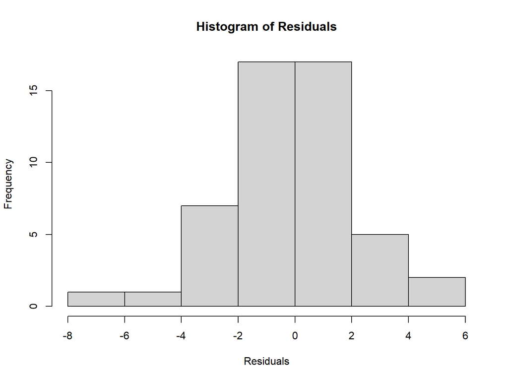

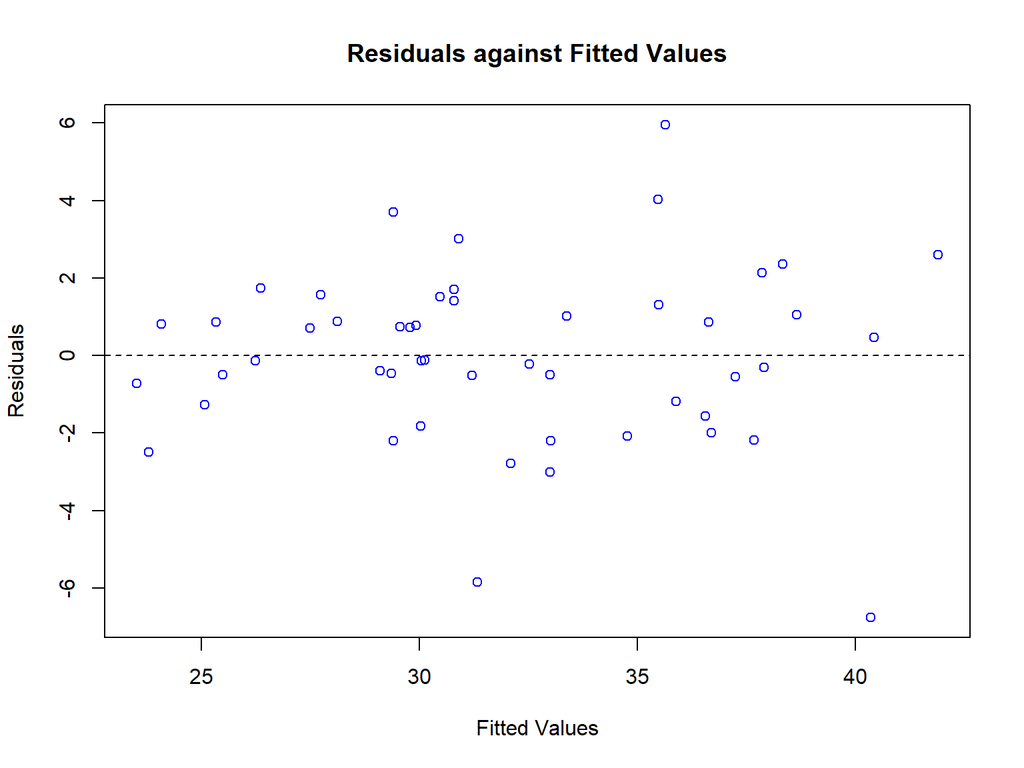

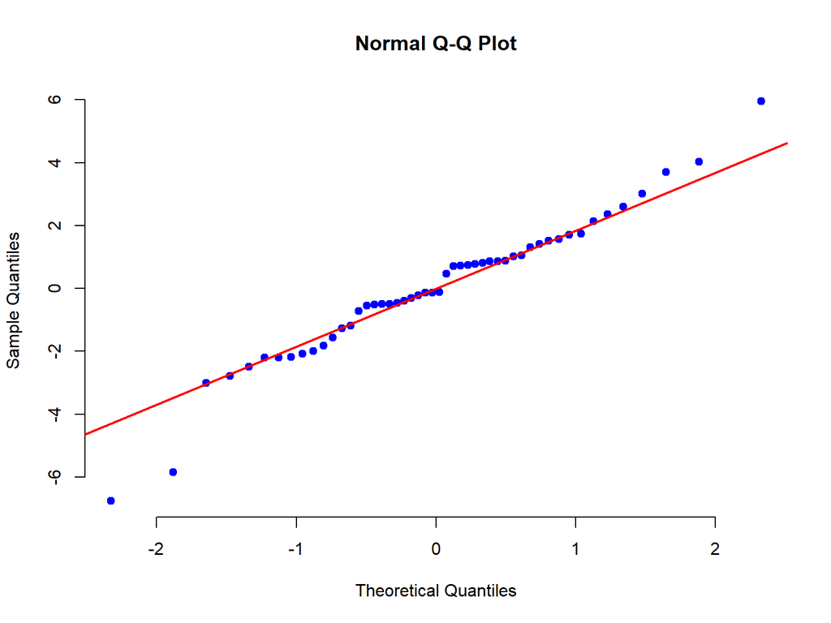

Prediction equation from the estimated coefficients:

```r
b <- round(coef(final_model), 4)
cat(sprintf("per_ba_hat = %.4f %+.4f(poverty_rate) %+.4f(teacher_pay) %+.4f(pup_teach_ratio) %+.4f(dem_rep_ratio_20)",
            b[1], b[2], b[3], b[4], b[5]))
```

```
## per_ba_hat = 30.3245 -0.8554(poverty_rate) +11.6836(teacher_pay) -0.1772(pup_teach_ratio) +3.9855(dem_rep_ratio_20)
```

### Multicollinearity

```r
round(vif(final_model), 4)
```

```
##     poverty_rate      teacher_pay  pup_teach_ratio dem_rep_ratio_20
##           1.4165           2.4045           1.1322           2.3048
```

All variance inflation factors fall below 2.5, the most conservative common threshold, chosen to offset the small number of observations.

## 7. Sensitivity analysis

How strong would an unobserved confounder need to be to explain away the association between poverty rate and bachelor’s attainment? This follows the [sensemakr vignette](https://cran.r-project.org/web/packages/sensemakr/vignettes/sensemakr.html), benchmarking against political lean.

```r
poverty_sensitivity <- sensemakr(model = final_model,
                                 treatment = "poverty_rate",
                                 benchmark_covariates = "dem_rep_ratio_20",
                                 kd = 1:3,
                                 reduce = TRUE)

summary(poverty_sensitivity)
```

[output not shown]

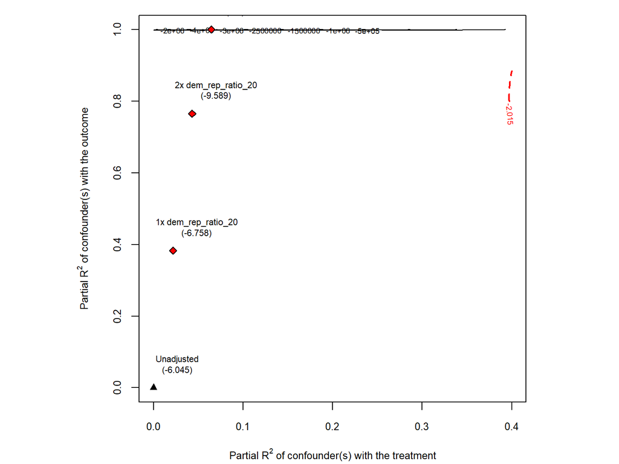

```r
plot(poverty_sensitivity, sensitivity.of = "t-value")
```

## Reproducibility notes

These notes document known issues in the 2023 analysis. They are kept here, unchanged, so the paper’s results can be reproduced exactly.

- **Missing-value codes.** In the data, `-1` marks a value the source didn’t report. Illinois and Utah have `pup_teach_ratio = -1`, and the final model treats those as real values instead of missing. Treating them as missing (n = 48) gives a similar model with a somewhat stronger fit.
- **Logistic model performance.** The paper describes the logistic models’ AUCs as “well under 40%.” Rerunning them on this dataset gives AUCs of about 0.51 to 0.83 (section 4), so the logistic models performed better than the paper reports. Linear regression was still the better fit for the research question.
- **Causal language.** The paper describes the four predictors as “drivers” of attainment. A cross-sectional, observational model like this one supports associations, not causal claims.